# data_analysis

```python
import os
import glob
import sox
import tqdm
import matplotlib
import numpy as np
import pandas as pd
import seaborn as sns
import matplotlib.pyplot as plt
from datetime import timedelta
from multiprocessing import Pool
from sklearn.preprocessing import StandardScaler
from sklearn.manifold import TSNE

%matplotlib inline
```

*datapath_root* contains directories with separated male and female voice recordings. The audio files were preprocessed to eliminate silent regions. Each directory contains a number of recordings of an individual and a README file with some metadata. The metadata is not uniform in structure. It might miss information or outright lie.

```python
num_parallel = 16
datapath_root = '/home/tracek/Data/gender/raw/'
datapath_male = os.path.join(datapath_root, 'male/')
datapath_female = os.path.join(datapath_root, 'female/')
```

Let's find all the recordings

```python
waves_male_paths = glob.glob(datapath_male + '/**/*.wav', recursive=True)
waves_female_paths = glob.glob(datapath_female + '/**/*.wav', recursive=True)
readme_paths = glob.glob(datapath_root + '/**/README', recursive=True)
```

Sanity check - do we always get a readme?

```python
assert len(os.listdir(datapath_male)) + len(os.listdir(datapath_female)) == len(readme_paths)
```

I am curious how long are all recordings and whether there are no empty recordings, where the algorithm for trimming silence got overly enthusiastic

```python
def get_info(path):
    info = sox.file_info.info(path)
    info['path'] = path
    if 'num_samples' not in info:
        print('No samples in ', path)
    return info
```

Let's do this in parallel. On my computer I am rarely IO bound - the beauty of ultra-fast NVMe drice (~3200 MB/s read)

```python
pool = Pool(processes=num_parallel)
male_info = pool.map(get_info, waves_male_paths)
female_info = pool.map(get_info, waves_female_paths)
```

For the future - check e.g. age range. Youth will have different vocal range

```python
def get_readme_info(path):
    d = {}
    with open(path, 'r') as readme:
        for line in readme:
            gender_match = re.search("Gender: (\W*\w+\W*)", line, re.IGNORECASE)
            age_match = re.search("Age Range: (\W*\w+\W*)", line, re.IGNORECASE)
            lang_match = re.search("Language: (\W*\w+\W*)", line, re.IGNORECASE)
```

Clearly there more guys talking

```python
duration_male = np.array([info['duration'] for info in male_info])
duration_female = np.array([info['duration'] for info in female_info])
total_male = int(duration_male.sum())
total_female = int(duration_female.sum())
print('Total duration of male recordings: {} '.format(str(timedelta(seconds=total_male))))
print('Total duration of female recordings: {} '.format(str(timedelta(seconds=total_female))))
```

```
Total duration of male recordings: 3 days, 15:03:21
Total duration of female recordings: 15:32:04
```

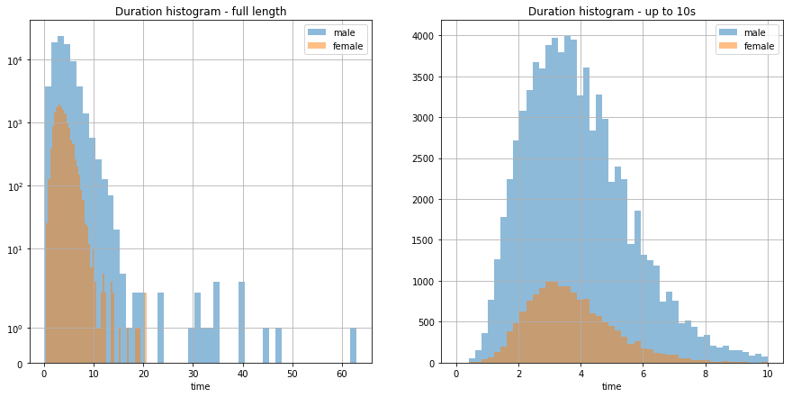

```python
no_bins = 50
fig, ax = plt.subplots(1,2, figsize=(15,7))
ax[0].set_yscale('symlog')
_ = ax[0].hist(duration_male, bins=no_bins, alpha=0.5, label='male')
_ = ax[0].hist(duration_female, bins=no_bins, alpha=0.5, label='female')
bins = np.linspace(0, 10, no_bins)
_ = ax[1].hist(duration_male, bins=bins, alpha=0.5, label='male')
_ = ax[1].hist(duration_female, bins=bins, alpha=0.5, label='female')
ax[0].legend(loc='upper right')
ax[0].set_title('Duration histogram - full length')
ax[0].set_xlabel('time')
ax[0].grid(True)
ax[1].legend(loc='upper right')
ax[1].set_title('Duration histogram - up to 10s')
ax[1].set_xlabel('time')
ax[1].grid(True)
```

```python
name_duration_tuples_m = [(info['path'], info['duration']) for info in male_info]
name_duration_tuples_m_short = [(info['path'], info['duration']) for info in male_info if info['duration'] < 0.5]
```

Very few short recordings - good

```python
len(name_duration_tuples_m_short)
```

```
12
```

Let's get some statistics

```python
datapath = '/home/tracek/Data/gender/gender_warbler.csv'
data = pd.read_csv(datapath)
male_df = data[data['label'] == 0]
female_df = data[data['label'] == 1]
print('Male recordings: ', len(male_df))
print('Female recordings: ', len(female_df))
pd.set_option('display.max_columns', len(male_df.columns.values))
pd.set_option('display.max_rows', len(male_df))

male_stats = male_df.describe()
female_stats = female_df.describe()

male_corr = male_df.corr()
female_corr = female_df.corr()
```

```
Male recordings:  78820
Female recordings:  15066
```

```python
male_stats
```

|  | meanfreq | sd | median | Q25 | Q75 | IQR | skew | kurt | sp.ent | sfm | mode | centroid | meanfun | minfun | maxfun | meandom | mindom | maxdom | dfrange | modindx | label |
| --- | --- | --- | --- | --- | --- | --- | --- | --- | --- | --- | --- | --- | --- | --- | --- | --- | --- | --- | --- | --- | --- |
| count | 78820.000000 | 78820.000000 | 78820.000000 | 78820.000000 | 78820.000000 | 78820.000000 | 78820.000000 | 78820.000000 | 78820.000000 | 78820.000000 | 78820.000000 | 78820.000000 | 78820.000000 | 78820.000000 | 78820.000000 | 78820.000000 | 78820.000000 | 78820.000000 | 78820.000000 | 78820.000000 | 78820.0 |
| mean | 0.158190 | 0.069968 | 0.155800 | 0.106229 | 0.217577 | 0.111348 | 5.315956 | 105.732651 | 0.913650 | 0.522978 | 0.113875 | 0.158190 | 0.111827 | 0.024538 | 0.238085 | 0.490626 | 0.046838 | 2.842126 | 2.795288 | 0.193379 | 0.0 |
| std | 0.029525 | 0.011912 | 0.040531 | 0.040964 | 0.030279 | 0.031203 | 7.640572 | 265.642245 | 0.056788 | 0.150907 | 0.082187 | 0.029525 | 0.021039 | 0.016960 | 0.040491 | 0.423132 | 0.080493 | 2.165304 | 2.149576 | 0.108625 | 0.0 |
| min | 0.000048 | 0.000924 | 0.000000 | 0.000000 | 0.000114 | 0.000114 | 0.096627 | 1.362474 | 0.081732 | 0.000029 | 0.000000 | 0.000048 | 0.016000 | 0.015640 | 0.016000 | 0.000000 | 0.000000 | 0.000000 | 0.000000 | 0.000000 | 0.0 |
| 25% | 0.142832 | 0.062430 | 0.129322 | 0.092997 | 0.205044 | 0.099816 | 1.817707 | 6.767020 | 0.899896 | 0.442717 | 0.049931 | 0.142832 | 0.098321 | 0.016194 | 0.219178 | 0.180060 | 0.000000 | 0.617188 | 0.585938 | 0.122613 | 0.0 |
| 50% | 0.159605 | 0.070046 | 0.152600 | 0.111946 | 0.222386 | 0.112615 | 2.460985 | 10.636244 | 0.922687 | 0.542471 | 0.116667 | 0.159605 | 0.111734 | 0.017817 | 0.253968 | 0.397569 | 0.000000 | 3.070312 | 3.015625 | 0.183710 | 0.0 |
| 75% | 0.177101 | 0.077571 | 0.183902 | 0.128866 | 0.237317 | 0.123661 | 3.532095 | 20.589989 | 0.940810 | 0.629068 | 0.166339 | 0.177101 | 0.123941 | 0.024206 | 0.271186 | 0.700120 | 0.085938 | 4.726562 | 4.664062 | 0.258026 | 0.0 |
| max | 0.260308 | 0.113707 | 0.270406 | 0.259467 | 0.276782 | 0.258316 | 51.242799 | 2774.534469 | 0.988251 | 0.907603 | 0.280000 | 0.260308 | 0.249851 | 0.197531 | 0.275862 | 4.855699 | 2.609375 | 6.992188 | 6.992188 | 1.000000 | 0.0 |

```python
female_stats
```

|  | meanfreq | sd | median | Q25 | Q75 | IQR | skew | kurt | sp.ent | sfm | mode | centroid | meanfun | minfun | maxfun | meandom | mindom | maxdom | dfrange | modindx | label |
| --- | --- | --- | --- | --- | --- | --- | --- | --- | --- | --- | --- | --- | --- | --- | --- | --- | --- | --- | --- | --- | --- |
| count | 15066.000000 | 15066.000000 | 15066.000000 | 15066.000000 | 15066.000000 | 15066.000000 | 15066.000000 | 15066.000000 | 15066.000000 | 15066.000000 | 15066.000000 | 15066.000000 | 15066.000000 | 15066.000000 | 15066.000000 | 15066.000000 | 15066.000000 | 15066.000000 | 15066.000000 | 15066.000000 | 15066.0 |
| mean | 0.185398 | 0.051220 | 0.190744 | 0.158069 | 0.219492 | 0.061423 | 3.109131 | 34.942888 | 0.883406 | 0.360126 | 0.176823 | 0.185398 | 0.166105 | 0.030376 | 0.256262 | 0.667128 | 0.100262 | 3.885722 | 3.785460 | 0.200783 | 1.0 |
| std | 0.027135 | 0.016517 | 0.031762 | 0.044361 | 0.024374 | 0.039292 | 4.204126 | 138.466819 | 0.049327 | 0.144613 | 0.064844 | 0.027135 | 0.022139 | 0.025143 | 0.021417 | 0.410212 | 0.080838 | 2.275746 | 2.250809 | 0.091063 | 0.0 |
| min | 0.000050 | 0.001123 | 0.000000 | 0.000000 | 0.000121 | 0.000121 | 0.058957 | 1.706946 | 0.082314 | 0.000043 | 0.000000 | 0.000050 | 0.041972 | 0.015640 | 0.086957 | 0.000000 | 0.000000 | 0.000000 | 0.000000 | 0.000000 | 1.0 |
| 25% | 0.177202 | 0.038919 | 0.181398 | 0.157535 | 0.204035 | 0.036971 | 1.711029 | 5.797064 | 0.861708 | 0.257301 | 0.170521 | 0.177202 | 0.156878 | 0.016789 | 0.246154 | 0.338033 | 0.000000 | 1.048828 | 1.015625 | 0.135274 | 1.0 |
| 50% | 0.188914 | 0.047223 | 0.194186 | 0.170499 | 0.220898 | 0.050785 | 2.219656 | 8.370690 | 0.888449 | 0.320151 | 0.188432 | 0.188914 | 0.169095 | 0.020000 | 0.262295 | 0.618518 | 0.148438 | 4.835938 | 4.695312 | 0.191833 | 1.0 |
| 75% | 0.202092 | 0.059854 | 0.208257 | 0.181184 | 0.236503 | 0.068883 | 2.912152 | 12.897301 | 0.911048 | 0.447784 | 0.211336 | 0.202092 | 0.179428 | 0.031311 | 0.271186 | 0.924594 | 0.164062 | 5.703125 | 5.585938 | 0.256827 | 1.0 |
| max | 0.252869 | 0.123865 | 0.270012 | 0.253907 | 0.276212 | 0.258962 | 46.825122 | 2308.549017 | 0.979994 | 0.855575 | 0.280000 | 0.252869 | 0.257717 | 0.225352 | 0.275862 | 2.927557 | 1.210938 | 6.992188 | 6.992188 | 1.000000 | 1.0 |

We can already notice that, as suspected, acoustic parameters differ for males and females. Are these parameters correlated?

|  | meanfreq | sd | median | Q25 | Q75 | IQR | skew | kurt | sp.ent | sfm | mode | centroid | meanfun | minfun | maxfun | meandom | mindom | maxdom | dfrange | modindx | label |
| --- | --- | --- | --- | --- | --- | --- | --- | --- | --- | --- | --- | --- | --- | --- | --- | --- | --- | --- | --- | --- | --- |
| meanfreq | 1.000000 | -0.531370 | 0.918285 | 0.908345 | 0.830313 | -0.386770 | -0.457958 | -0.417237 | 0.159927 | -0.499641 | 0.655460 | 1.000000 | 0.309700 | 0.120628 | -0.113266 | 0.414225 | 0.449952 | 0.350724 | 0.336441 | 0.281725 | NaN |
| sd | -0.531370 | 1.000000 | -0.441099 | -0.682203 | -0.086575 | 0.811592 | 0.410973 | 0.388134 | 0.243810 | 0.642498 | -0.522495 | -0.531370 | -0.127773 | -0.057107 | 0.111296 | -0.284795 | -0.365445 | -0.286867 | -0.275282 | -0.177614 | NaN |
| median | 0.918285 | -0.441099 | 1.000000 | 0.772453 | 0.711091 | -0.324061 | -0.342813 | -0.301344 | 0.147395 | -0.407684 | 0.601589 | 0.918285 | 0.225871 | 0.042936 | -0.055700 | 0.394752 | 0.423723 | 0.304268 | 0.290627 | 0.219111 | NaN |
| Q25 | 0.908345 | -0.682203 | 0.772453 | 1.000000 | 0.653534 | -0.678638 | -0.499486 | -0.469299 | 0.075059 | -0.512691 | 0.635642 | 0.908345 | 0.337124 | 0.150121 | -0.125235 | 0.371944 | 0.423727 | 0.328561 | 0.315098 | 0.296324 | NaN |
| Q75 | 0.830313 | -0.086575 | 0.711091 | 0.653534 | 1.000000 | 0.112408 | -0.337403 | -0.303856 | 0.265974 | -0.244582 | 0.456325 | 0.830313 | 0.260794 | 0.154114 | -0.114132 | 0.292881 | 0.287644 | 0.246390 | 0.237422 | 0.248244 | NaN |
| IQR | -0.386770 | 0.811592 | -0.324061 | -0.678638 | 0.112408 | 1.000000 | 0.328323 | 0.321247 | 0.159556 | 0.435730 | -0.391672 | -0.386770 | -0.189511 | -0.047532 | 0.053659 | -0.204088 | -0.277151 | -0.192247 | -0.183275 | -0.148128 | NaN |
| skew | -0.457958 | 0.410973 | -0.342813 | -0.499486 | -0.337403 | 0.328323 | 1.000000 | 0.978248 | -0.423898 | 0.008372 | -0.526812 | -0.457958 | -0.272721 | -0.158513 | 0.146785 | -0.397926 | -0.208972 | -0.438794 | -0.434180 | -0.484166 | NaN |
| kurt | -0.417237 | 0.388134 | -0.301344 | -0.469299 | -0.303856 | 0.321247 | 0.978248 | 1.000000 | -0.397813 | 0.008904 | -0.476433 | -0.417237 | -0.251485 | -0.157671 | 0.150416 | -0.367938 | -0.194626 | -0.403165 | -0.398827 | -0.471864 | NaN |
| sp.ent | 0.159927 | 0.243810 | 0.147395 | 0.075059 | 0.265974 | 0.159556 | -0.423898 | -0.397813 | 1.000000 | 0.590999 | 0.050762 | 0.159927 | 0.060196 | -0.065375 | 0.068242 | 0.121628 | -0.091384 | 0.177869 | 0.182592 | 0.186912 | NaN |
| sfm | -0.499641 | 0.642498 | -0.407684 | -0.512691 | -0.244582 | 0.435730 | 0.008372 | 0.008904 | 0.590999 | 1.000000 | -0.341765 | -0.499641 | -0.183386 | -0.100184 | 0.096793 | -0.132090 | -0.327100 | -0.105780 | -0.094306 | 0.000530 | NaN |
| mode | 0.655460 | -0.522495 | 0.601589 | 0.635642 | 0.456325 | -0.391672 | -0.526812 | -0.476433 | 0.050762 | -0.341765 | 1.000000 | 0.655460 | 0.201729 | 0.153088 | -0.170067 | 0.389690 | 0.443671 | 0.347388 | 0.333316 | 0.256782 | NaN |
| centroid | 1.000000 | -0.531370 | 0.918285 | 0.908345 | 0.830313 | -0.386770 | -0.457958 | -0.417237 | 0.159927 | -0.499641 | 0.655460 | 1.000000 | 0.309700 | 0.120628 | -0.113266 | 0.414225 | 0.449952 | 0.350724 | 0.336441 | 0.281725 | NaN |
| meanfun | 0.309700 | -0.127773 | 0.225871 | 0.337124 | 0.260794 | -0.189511 | -0.272721 | -0.251485 | 0.060196 | -0.183386 | 0.201729 | 0.309700 | 1.000000 | 0.302264 | 0.143757 | 0.233844 | 0.096639 | 0.224012 | 0.222032 | 0.212940 | NaN |
| minfun | 0.120628 | -0.057107 | 0.042936 | 0.150121 | 0.154114 | -0.047532 | -0.158513 | -0.157671 | -0.065375 | -0.100184 | 0.153088 | 0.120628 | 0.302264 | 1.000000 | -0.254629 | 0.057173 | 0.174438 | -0.030728 | -0.037485 | 0.287109 | NaN |
| maxfun | -0.113266 | 0.111296 | -0.055700 | -0.125235 | -0.114132 | 0.053659 | 0.146785 | 0.150416 | 0.068242 | 0.096793 | -0.170067 | -0.113266 | 0.143757 | -0.254629 | 1.000000 | -0.019064 | -0.218438 | 0.062438 | 0.071074 | -0.224046 | NaN |
| meandom | 0.414225 | -0.284795 | 0.394752 | 0.371944 | 0.292881 | -0.204088 | -0.397926 | -0.367938 | 0.121628 | -0.132090 | 0.389690 | 0.414225 | 0.233844 | 0.057173 | -0.019064 | 1.000000 | 0.450313 | 0.731991 | 0.720485 | 0.381278 | NaN |
| mindom | 0.449952 | -0.365445 | 0.423723 | 0.423727 | 0.287644 | -0.277151 | -0.208972 | -0.194626 | -0.091384 | -0.327100 | 0.443671 | 0.449952 | 0.096639 | 0.174438 | -0.218438 | 0.450313 | 1.000000 | 0.213274 | 0.177389 | 0.257251 | NaN |
| maxdom | 0.350724 | -0.286867 | 0.304268 | 0.328561 | 0.246390 | -0.192247 | -0.438794 | -0.403165 | 0.177869 | -0.105780 | 0.347388 | 0.350724 | 0.224012 | -0.030728 | 0.062438 | 0.731991 | 0.213274 | 1.000000 | 0.999331 | 0.001493 | NaN |
| dfrange | 0.336441 | -0.275282 | 0.290627 | 0.315098 | 0.237422 | -0.183275 | -0.434180 | -0.398827 | 0.182592 | -0.094306 | 0.333316 | 0.336441 | 0.222032 | -0.037485 | 0.071074 | 0.720485 | 0.177389 | 0.999331 | 1.000000 | -0.008129 | NaN |
| modindx | 0.281725 | -0.177614 | 0.219111 | 0.296324 | 0.248244 | -0.148128 | -0.484166 | -0.471864 | 0.186912 | 0.000530 | 0.256782 | 0.281725 | 0.212940 | 0.287109 | -0.224046 | 0.381278 | 0.257251 | 0.001493 | -0.008129 | 1.000000 | NaN |
| label | NaN | NaN | NaN | NaN | NaN | NaN | NaN | NaN | NaN | NaN | NaN | NaN | NaN | NaN | NaN | NaN | NaN | NaN | NaN | NaN | NaN |

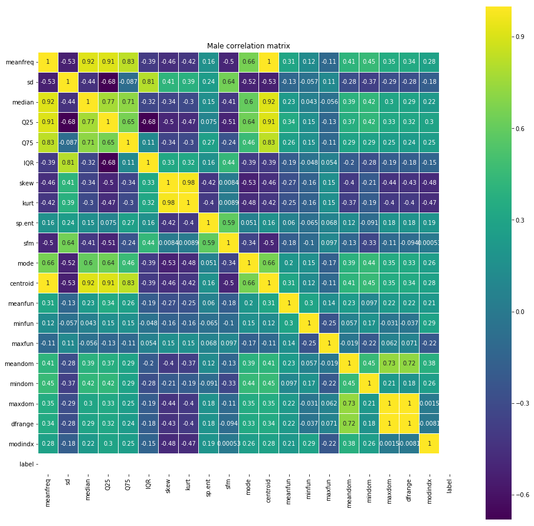

```python
plt.figure(figsize=(16, 16))
plt.title('Male correlation matrix')

sns.heatmap(male_corr,
            xticklabels=male_corr.columns.values,
            yticklabels=male_corr.columns.values,
            linewidths=0.2,
            vmax=1.0,
            square=True,
            cmap=plt.cm.viridis,
            linecolor='white',
            annot=True)

male_corr
```

[output not shown]

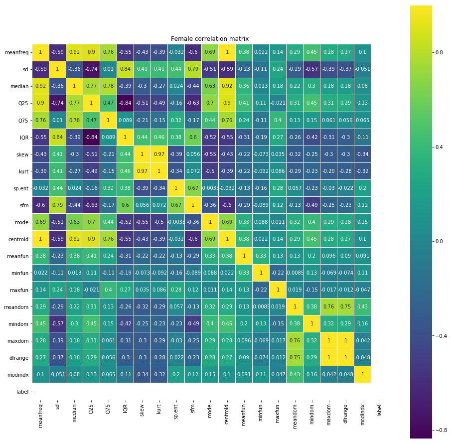

```python
plt.figure(figsize=(16, 16))
plt.title('Female correlation matrix')

sns.heatmap(female_corr,
            xticklabels=female_corr.columns.values,
            yticklabels=female_corr.columns.values,
            linewidths=0.2,
            vmax=1.0,
            square=True,
            cmap=plt.cm.viridis,
            linecolor='white',
            annot=True)

female_corr
```

Before we move further, let's make sure data types are OK

```python
data.dtypes
```

```
filename     object
meanfreq    float64
sd          float64
median      float64
Q25         float64
Q75         float64
IQR         float64
skew        float64
kurt        float64
sp.ent      float64
sfm         float64
mode        float64
centroid    float64
meanfun     float64
minfun      float64
maxfun      float64
meandom     float64
mindom      float64
maxdom      float64
dfrange     float64
modindx     float64
label         int64
dtype: object
```

We already know we can drop some features. *Filename* is also of little use. Let's rehearse what features are at our disposal:

- meanfreq: mean frequency (in kHz)
- sd: standard deviation of frequency
- median: median frequency (in kHz)
- Q25: first quantile (in kHz)
- Q75: third quantile (in kHz)
- IQR: interquantile range (in kHz)
- skew: skewness
- kurt: kurtosis
- sp.ent: spectral entropy
- sfm: spectral flatness
- mode: mode frequency
- meanfun: average of fundamental frequency measured across acoustic signal
- minfun: minimum fundamental frequency measured across acoustic signal
- maxfun: maximum fundamental frequency measured across acoustic signal
- meandom: average of dominant frequency measured across acoustic signal
- mindom: minimum of dominant frequency measured across acoustic signal
- maxdom: maximum of dominant frequency measured across acoustic signal

```python
y = data.pop('label')
data = data.drop(['centroid', 'dfrange', 'filename'], axis=1)
X = StandardScaler().fit_transform(data)
```

With the collected features, is it possible at tell the gender apart? Based on common experience - yes. After all, we can usually distinguish gender by voice, and we do this by interpreting acoustic properties of the signal. Female voice sounds higher. Let's see if we can somehow check it.

We have 18 features, meaning 18-dimensional space. As 3-d creatures, we barely manage with our imagination in 3-d and 2-d is by far preferred. One of the most accomplished methods for 2-d embedding of high-dimensional spaces is t-SNE: t-distributed stochastic neighbor embedding.

Wiki: https://en.wikipedia.org/wiki/T-distributed_stochastic_neighbor_embedding

```python
tsne = TSNE(n_components=2, init='pca', random_state=0)
X = tsne.fit_transform(X)
```

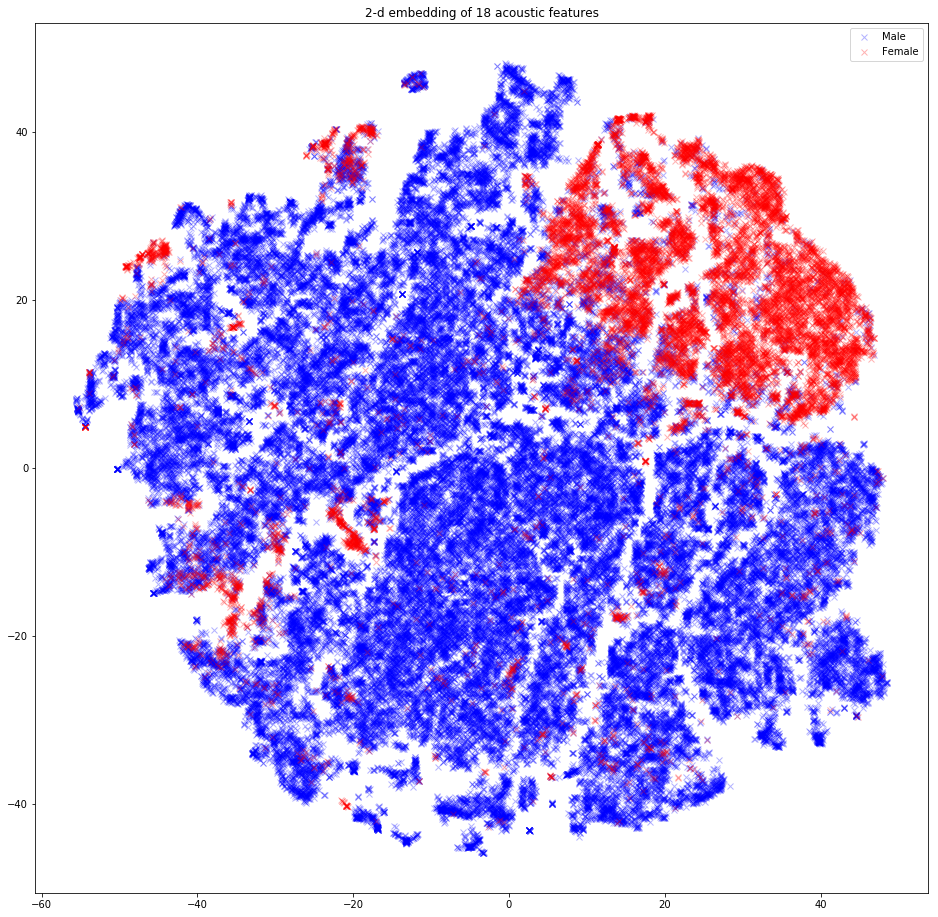

```python
plt.figure(figsize=(16, 16))
plt.title('2-d embedding of 18 acoustic features')
plt.scatter(X[np.where(y == 0), 0],
            X[np.where(y == 0), 1],
            marker='x', color='b',
            linewidth='1', alpha=0.3, label='Male')
plt.scatter(X[np.where(y == 1), 0],
            X[np.where(y == 1), 1],
            marker='x', color='r',
            linewidth='1', alpha=0.3, label='Female')
plt.legend()
```

Looks great! Clearly male and female can be **somehow** separated. Why females seem to be grouped in a corner why guys are dominating the plot? Remember that there are 5 times more males! Not only that, they also seem to represent much wider acoustic spectrum through e.g. various accents.

We can read on Wiki (https://en.wikipedia.org/wiki/Voice_frequency) that typically fundamental frequency is different for males and females. Let's see if it holds with our data.

```python
data = pd.read_csv(datapath).drop(['centroid', 'dfrange', 'filename'], axis=1)
```

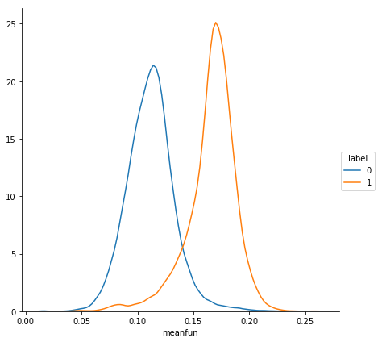

```python
sns.FacetGrid(data, hue="label", size=6).map(sns.kdeplot, "meanfun").add_legend()
```

Very promising! Let's see how it looks like for all features.

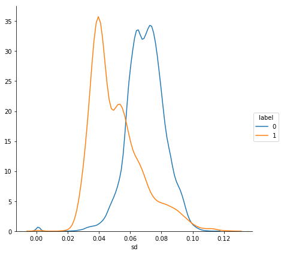

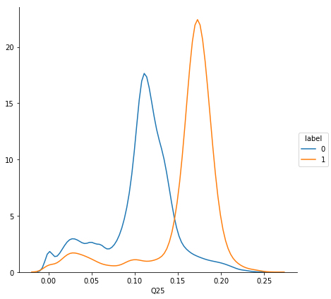

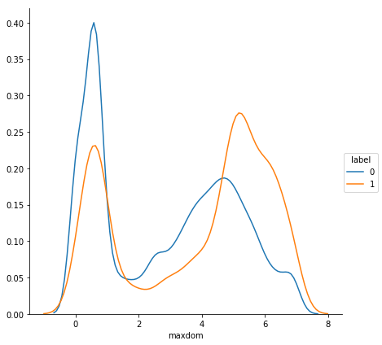

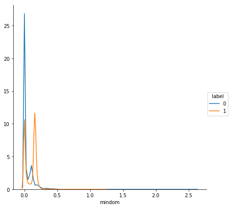

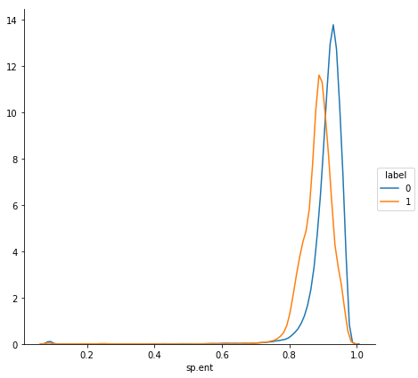

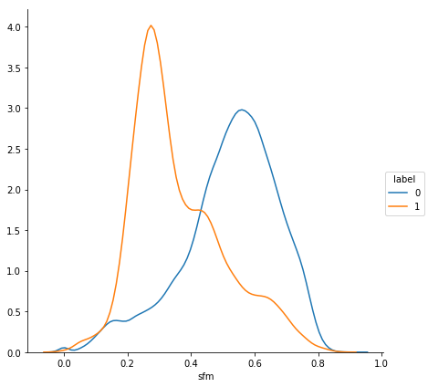

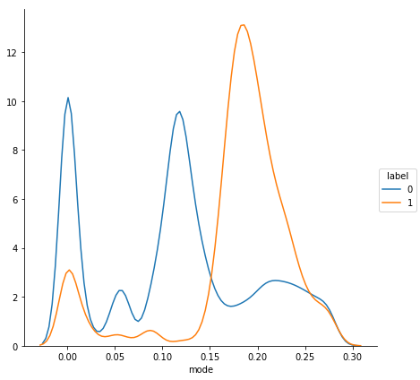

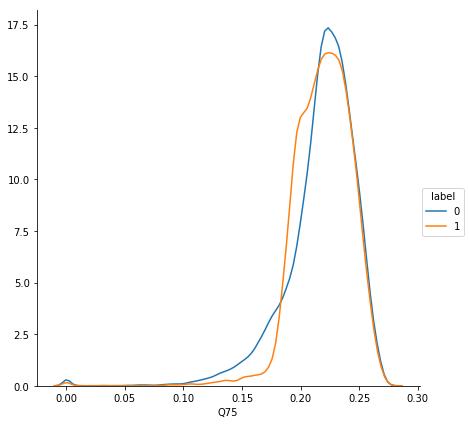

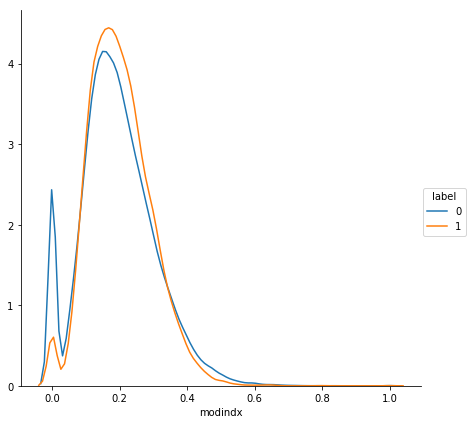

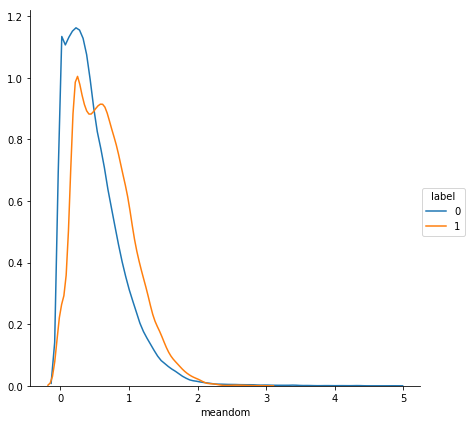

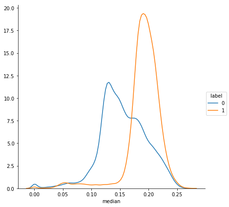

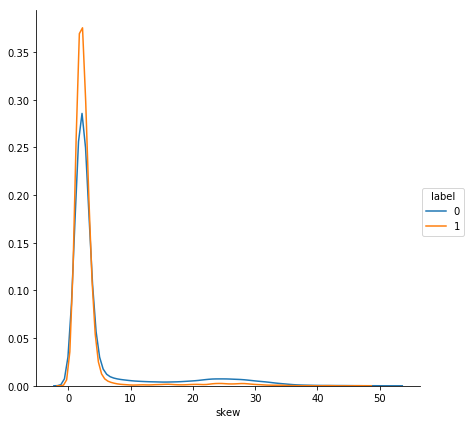

[6 more figures not shown]

```python
for name in (set(data.columns.values) - {'label'}):
    sns.FacetGrid(data, hue="label", size=6).map(sns.kdeplot, name).add_legend()
```

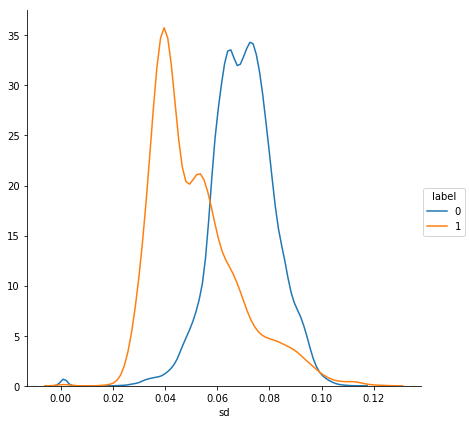

```python
sns.FacetGrid(data, hue="label", size=6).map(sns.kdeplot, "sd").add_legend()
```